# Assignment (Due 4/18 by 11:59 PM)

## Lab 2

Sentiment analysis is a tool for assessing the mood of a piece of text. For example, we can use sentiment analysis to understand public perceptions of topics in environmental policy like energy, climate, and conservation.

#### 1. Access the Nexis Uni database through the UCSB library: https://www.library.ucsb.edu/research/db/211

#### 2. Choose a key search term or terms to define a set of articles.

In this lab, I will be exploring the words *‘blue cabron’* and *‘mangrove’*. I am particularly interested in investigating the relationship between positivism and negativism as they relate to political and government initiatives in the environment.

[Here](https://search.library.ucsb.edu/discovery/search?query=any,contains,blue%20carbon&tab=Everything&search_scope=DN_and_CI&vid=01UCSB_INST:UCSB&lang=en&offset=0) is a link that takes you to the related articles from the Univeristy of California data base.

#### 3. Use your search term along with appropriate filters to obtain and download a batch of at least 100 full text search results (.docx)

#### 4. Read your Nexis article document into RStudio.

#### 5. This time use the full text of the articles for the analysis. First clean any artifacts of the data collection process (hint: this type of thing should be removed: “Apr 04, 2022 (Biofuels Digest: http://www.biofuelsdigest.com/ Delivered by Newstex”))

It appears that the composition of the text is not being impacted by any artifacts in this particular section, so im going to leave the tibbles as they come.

#### 6. Explore your data a bit and replicate the analyses above presented in class (Lab2)

```r
# The @ is for indexing within tibbles
meta_df <- text_dat@meta
articles_df <- text_dat@articles
paragraphs_df <- text_dat@paragraphs

dat2 <- tibble(Date = meta_df$Date,
              Headline = meta_df$Headline,
              id = text_dat@articles$ID,
              text = text_dat@articles$Article)
```

Next, we will calculate the average sentiment score of words in the filtered articles using the stop_words and bing_sentiment datasets.

```r
mean(sentiment_words$sent_num)
```

```
## [1] 0.422933
```

Now lets calculate mean sentiment (by word polarity) across articles

```r
sentiment_article <- sentiment_words |>
  group_by(Headline) |>
  count(id, sentiment) |>
  pivot_wider(names_from = sentiment,
              values_from = n,
              values_fill = 0) |>
  mutate(polarity = positive - negative)

mean(sentiment_article$polarity)
```

```
## [1] 9.635659
```

Upon this analysis, it is evident that the average sentiment score per article (9.63) is considerably higher than that of words (0.43).

Now, let’s examine the sentiment distribution of articles by plotting a graph, in order to visualize the proportion of positive and negative articles.

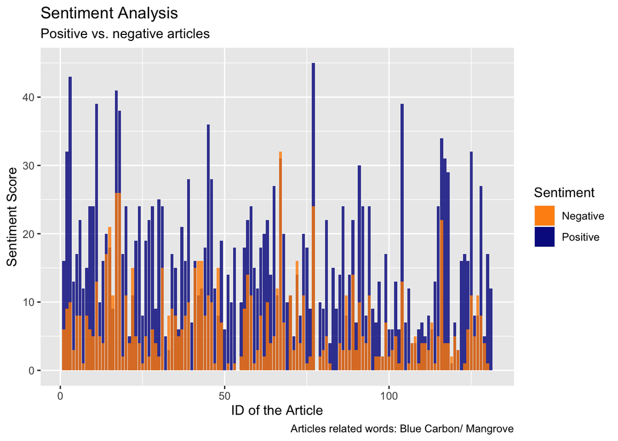

```r
ggplot(sentiment_article, aes(x = id)) +
  geom_col(aes(y = positive, fill = "Positive"), alpha = 0.8) +
  geom_col(aes(y = negative, fill = "Negative"), alpha = 0.8) +
  labs(title = "Sentiment Analysis",
       subtitle = "Positive vs. negative articles",
       caption = "Articles related words: Blue Carbon/ Mangrove",
       y = "Sentiment Score",
       x = "ID of the Article",
       fill = "Sentiment") +
  scale_fill_manual(values = c("darkorange", "darkblue"),
                    labels = c("Negative", "Positive"),
                    name = "Sentiment")
```

#### 7. Look at the nrc contribution to emotion by word plots. Identify and reclassify or remove at least one term that gives misleading results in your context.

```r
# Create a new data frame with the sentiments per word.
word_sentiment <- get_sentiments("nrc") |>
  filter(word != "blue") #Remove the word blue because is misleading
```

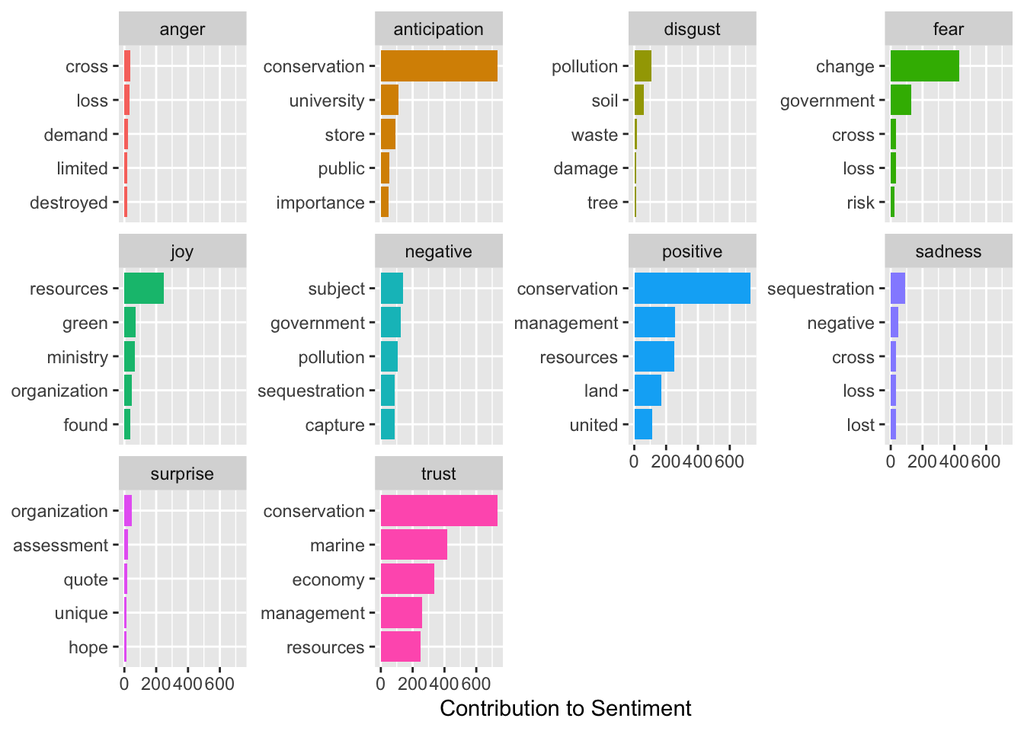

#### 8. Plot the amount of nrc emotion words as a percentage of all the emotion words used each day (aggregate text from articles published on the same day).

How does the distribution of emotion words change over time? Can you think of any reason this would be the case? Plot all the emotion word from the article. What percentage is for the emotion and how it changes over time.

**Fun Fact:** The NRC lexicon was created by selecting 10,000 words from a thesaurus and asking a set of five questions about each word to reveal associated emotions and polarity. Over 50,000 questions were asked to over 2,000 people on Amazon’s Mechanical Turk website, resulting in a comprehensive word-emotion lexicon for over 10,000 words. The Turkers were paid 4 cents for each set of properly answered questions.

```r
words_time <- text_words |>
  select(id , date = Date, word) |>
  mutate(date = as.Date(date, format = "%B %d, %Y")) |>
  anti_join(stop_words, by= "word") |>
  inner_join(bing_sent) |>
  rename(bing = sentiment) |>
  mutate(bing_num = case_when(bing == "negative" ~ -1,
                              bing == "positive" ~ 1)) |>
  inner_join(word_sentiment) |>
  rename(nrc = sentiment)
colors <- c("positive" = "green",
            "anticipation" = "cyan2",
            "joy" = "pink",
            "trust" = "coral",
            "negative" = "red",
            "sadness" = "gray30",
            "anger" = "darkorchid3",
            "disgust" = "black",
            "fear" = "darkred",
            "surprise" = "gold")
```

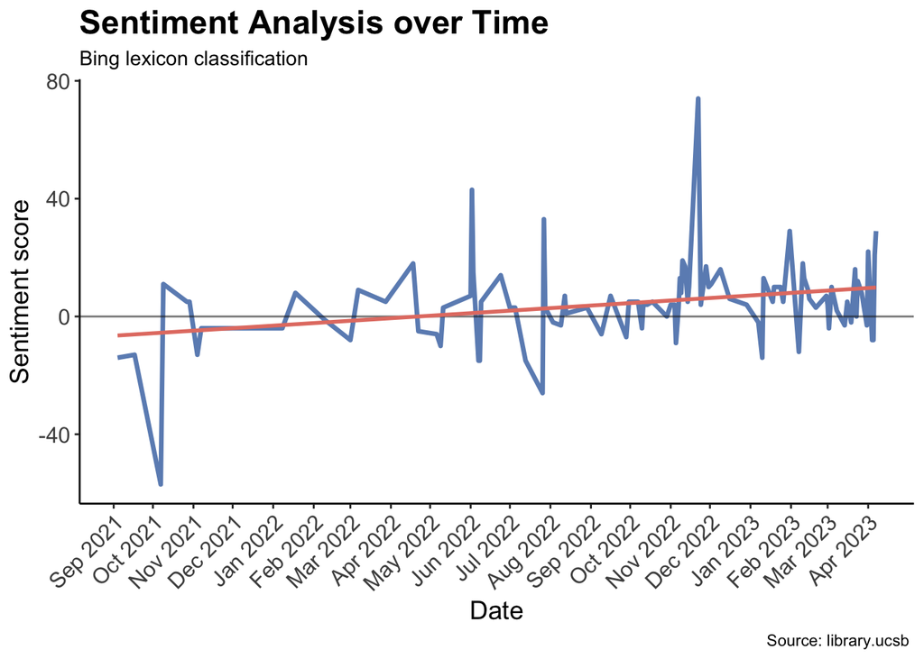

```r
words_time %>%
  filter(date >= as.Date("2021-1-1")) |>
  group_by(date) %>%
  summarise(bing_num = sum(bing_num)) %>%
  ggplot(aes(x = date, y = bing_num)) +
  geom_line(color = "#6C8EBF", size = 1.2) +
  geom_hline(yintercept = 0, color = "gray10", size = 0.5, alpha = 0.6 ) +
  geom_smooth(method = lm,
              se = FALSE,
              color = "#E47E72") +
  labs(x = "Date", y = "Sentiment score",
       title = "Sentiment Analysis over Time",
       subtitle = "Bing lexicon classification",
       caption = "Source: library.ucsb ") +
  theme_classic() +
  theme(plot.title = element_text(face = "bold", size = 18),
        axis.text = element_text(size = 12),
        axis.title = element_text(size = 14),
        axis.text.x = element_text(angle = 45, vjust = 1, hjust = 1)) +
  scale_x_date(date_labels = "%b %Y",
               breaks = seq(as.Date("2021-01-01"),
                            as.Date("2023-04-16"), by = "1 month"))
```

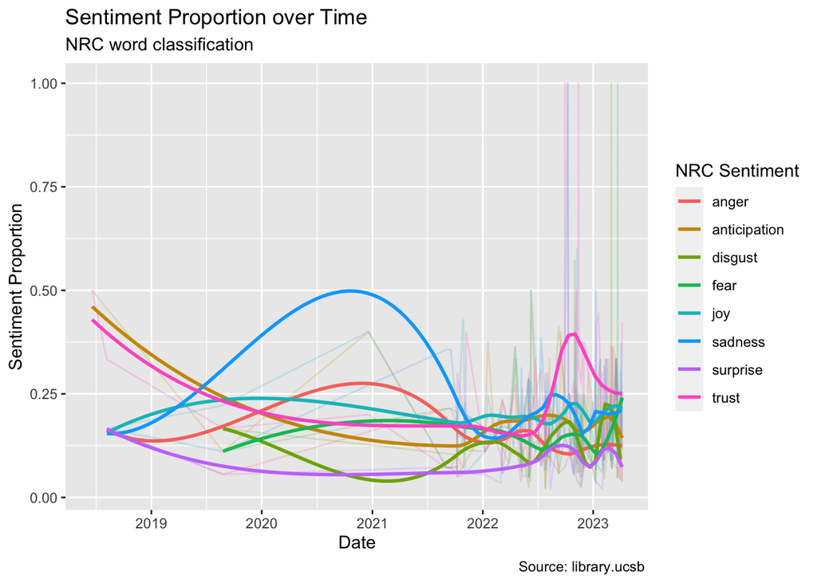

```r
words_time |>
  filter(nrc %in% c("anticipation", "joy", "trust", "sadness", "anger", "disgust" ,"fear", "surprise")) |>
  group_by(date, nrc) |>
  summarise(word_appearance = n()) |>
  ungroup() |>
  group_by(date) |>
  mutate(tot_appearance = sum(word_appearance)) |>
  mutate(proportion = word_appearance/tot_appearance) |>
  ggplot(aes(x=date, y= proportion, color = nrc)) +
  geom_line(alpha = 0.2) +
  geom_smooth(method = "loess",
              se = F,
              span = 0.5,
              alpha = 0.4) +
  labs(x = "Date",
       y = "Sentiment Proportion",
       color = "NRC Sentiment",
       title = "Sentiment Proportion over Time",
       subtitle = "NRC word classification",
       caption = "Source: library.ucsb ")
```

Below, you can see the total distribution of sentiments across our database.

```r
# Compute the proportion of each category
nrc_proportions <- words_time %>%
  count(nrc) %>%
  mutate(proportion = n / sum(n))

nrc_proportions %>%
  mutate(proportion = sprintf("%.2f%%", proportion * 100)) %>% # Multiply by 100 and format as percentage
  kable(format = "html", align = "c") %>%
  kable_styling(full_width = F,
                bootstrap_options = "striped",
                position = "center",
                font_size = 16)
```

| nrc | n | proportion |
| --- | --- | --- |
| anger | 153 | 5.28% |
| anticipation | 235 | 8.11% |
| disgust | 104 | 3.59% |
| fear | 188 | 6.49% |
| joy | 264 | 9.11% |
| negative | 514 | 17.74% |
| positive | 780 | 26.92% |
| sadness | 241 | 8.32% |
| surprise | 69 | 2.38% |
| trust | 349 | 12.05% |

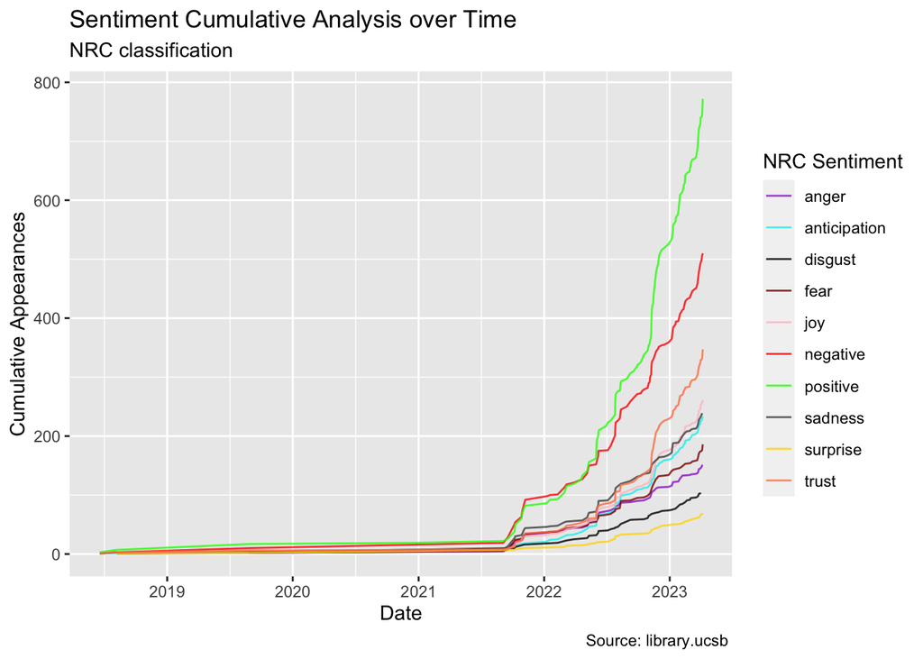

```r
words_time %>%
  group_by(date, nrc) %>%
  summarise(appearance = n()) %>%
  group_by(nrc) %>%
  mutate(cum_appearance = cumsum(appearance)) %>%
  ungroup() %>%
  arrange(desc(cum_appearance)) |>
  ggplot(aes(x = date, y = cum_appearance, color = nrc)) +
  geom_line(alpha = 0.8) +
   scale_color_manual(values = colors) +
  labs(x = "Date",
       y = "Cumulative Appearances",
       color = "NRC Sentiment",
       title = "Sentiment Cumulative Analysis over Time",
       subtitle = "NRC classification",
       caption = "Source: library.ucsb ")
```

In the above graph, I have calculated a cumulative score for each sentiment to gain insight into the overall trends of words and vibes used in the articles. This plot also highlights the high influx of articles in recent years. As anticipated, the positive and negative sentiments have the highest scores, but the positive line surpasses the negative line by a significant margin. Additionally, there are noteworthy correlations between certain words and the sentiments of trust, joy, and sadness, which have seen increased usage in recent times. Conversely, surprise and disgust are used less frequently, representing the less common sentiments.